# Data cleaning and identifier mapping

Assignment 1 for BCB420 Winter 2023

Jielin Yang

Feb. 14th, 2023

# 1 Introduction

## 1.1 Background

Heart failure (HF) is one of the most common and life-threatening syndrome associated with progressive morbidity and mortality that has implicated over 65 million patients worldwide in 2017.<sup>1</sup> It is characterized by the reduced capacity of the heart to pump sufficient blood to meet the metabolic demands of the body. The pathogenesis of HF is complex and involves multiple factors, but one of the earliest hallmark of the disease is maladaptive remodelling of the myocardium.<sup>2</sup> During remodelling, the damaged cardiomyocytes (which can be resulted from ventricular overload, altered metabolic composition, etc.) are replaced by fibrotic scar tissues.<sup>3</sup> <sup>4</sup> The altererd extracellular matrix (ECM) increased myocardial stiffness and thus further contributes to the progression of HF.<sup>5</sup> Therefore, the identification of the key genes and pathways that are involved in profibrotic remodeling is critical for the development of novel therapeutic teachniques.

Earlier studies have established a connection between both static and dynamic cytoskeletal tension between cells as a result of cellular adhesion to ECM with the transactivation of the Hippo signaling pathway.<sup>6</sup> In particular, it was found that an increased nuclear entry of the YAP/TAZ complex, which is a potent transcriptional activator of proliferative genes, is a result of the inhibition of the repressive kinease regulators and deformation of the nuclear lamina under mechanical strains.<sup>7</sup> <sup>8</sup> Recently, this finding has been extended to myofibroblasts, which are the major contributor of cardiac fibrosis derived from the quiescence cardiac stromal cells .<sup>9</sup> Hence, [Garoffolo et al.](https://doi.org/10.1161/CIRCRESAHA.121.319373) aims to elicidate the connection between the abnormal straining forces in cardiac myocardium and the YAP-dependent transcriptional activation in profibrotic cells.<sup>2</sup> In addition, they tested whether direct pharmaceutical inhibition of the YAP/TAZ complex with verteporfin (VTP), a known drug that interferes the binding of YAP to its target TEAD, can attenuate the progression of cardiac fibrosis with and without the presence of the potent profibrotic cytokine TGF-β1.<sup>10</sup> <sup>11</sup>

## 1.2 Objectives

The research study aimed to establish the connection between the response of human myocardial stromal cells (cSt-Cs) to straining forces and the activation of the profibrotic pathway downsteam of YAP/TAZ. In addition, they tested whether the inhibition of YAP/TAZ translocation to the nucleus is sufficient to produce an antifibrotic effect.<sup>2</sup>

Here, we focused on a particular part of the larger objective, where we incorporated the RNA sequencing data to differentially compare the molecular signitures of the cSt-Cs under known mechanical strains that activate profibrotic pathways. We hope to identify whether the direct inactivation of the YAP/TAZ complex with VTP under *in vitro* conditions is able to attenuate the progression of cardiac fibrosis, with and without the presence of TGF-β.<sup>2</sup>

## 1.3 Data

As documented in the previous [journal](https://github.com/bcb420-2023/Jielin_Yang/wiki/Gene-Expression-Dataset-Selection) and [R Notebook](https://github.com/bcb420-2023/Jielin_Yang/blob/main/Data%20set%20selection%20and%20initial%20processing/Gene_Expression_Dataset_Selection.Rmd), we have performed a search for gene expression datasets that are related to the topic of our research project using both the GEOmetadb and the NCBI GEO database. Upon reviewing the results, we have selected the dataset with the accession number GSE203358 for further analysis. This dataset is part of a study that has been published in Circulation Research. The original publication can be found [here](https://doi.org/10.1161/CIRCRESAHA.121.319373).

## 1.4 Study Summary

### 1.4.1 Publication Title

Reduction of Cardiac Fibrosis by Interference With YAP-Dependent Transactivation

### 1.4.2 General Experimental Design

To access whether direct inhibition of the YAP/TAZ complex contributes to anti-fibrotic activities under chronic mechanical strain and profibrotic signalling, RNA sequencing was performed in the following way. Cardiospheres-derived primitive cardiac stromal cells (cSt-Cs) were derived from cardiospheres retrieved from human myocardial explant tissues. cSt-Cs were then treated with ±verteporfin (VTP) and ±TGF-β1 under *in vitro* culture conditions under maximum strain exerted by glass slides. Total RNA was extracted from each independent cell culture 72 hours after phamalogical treatments using the Trizol method. RNA library was made following enrichment of the polyadenylated mRNAs.

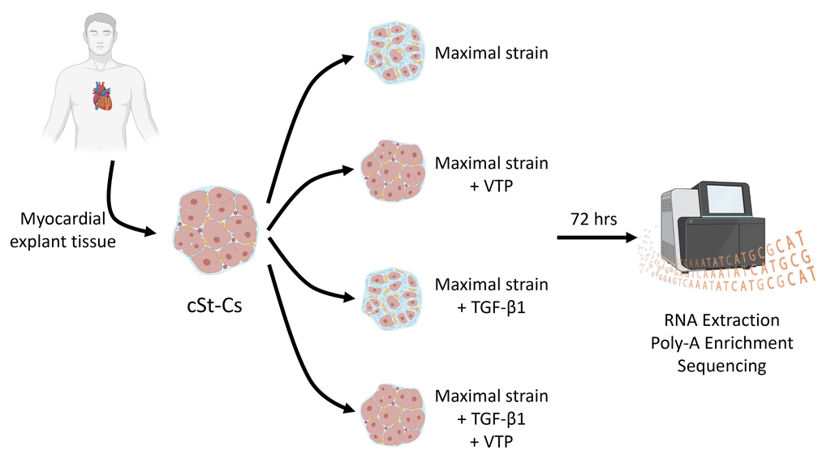

**Figrue 1.** Schematics of RNAseq experiment design. Samples were cultured under maximal mechanical strains. Six independent cell cultures were used for each treatment condition. cSt-Cs: cardiospheres-derived primitive cardiac stromal cells; VTP: verteporfin; TGF-β1: transforming growth factor beta-1. Figure created with BioRender.com

# 2 Preparations

The current R Notebook assumes that it is being run on the BCB420-2023 base image. Additional packages required are noted below.

```r
# BiocManager for installing a set of Bioconductor packages
if (!requireNamespace("BiocManager", quietly = TRUE)) {
    install.packages("BiocManager")
}

# GEOquery package for querying the GEO database
if (!requireNamespace("GEOquery", quietly = TRUE)) {
    BiocManager::install("GEOquery")
}

# edgeR package for manupulating and analyzing RNAseq data
if (!requireNamespace("edgeR", quietly = TRUE)) {
    BiocManager::install("edgeR")
}

# limma package for manupulating and analyzing RNAseq data
if (!requireNamespace("limma", quietly = TRUE)) {
    BiocManager::install("limma")
}

# biomaRt package for querying the Ensembl database
if (!requireNamespace("biomaRt", quietly = TRUE)) {
    BiocManager::install("biomaRt")
}

# stringr package for string manipulation
if (!requireNamespace("stringr", quietly = TRUE)) {
    install.packages("stringr")
}

# KableExtra package for creating tables and formatting
if (!requireNamespace("kableExtra", quietly = TRUE)) {
    install.packages("kableExtra")
}

# dplyr package for data manipulation
if (!requireNamespace("dplyr", quietly = TRUE)) {
    install.packages("dplyr")
}

# DT package for creating interactive tables
if (!requireNamespace("DT", quietly = TRUE)) {
    install.packages("DT")
}

# ggplot2 package for data visualization
if (!requireNamespace("ggplot2", quietly = TRUE)) {
    install.packages("ggplot2")
}

# reshape2 package for data manipulation
if (!requireNamespace("reshape2", quietly = TRUE)) {
    install.packages("reshape2")
}

# here package for file path management
if (!requireNamespace("here", quietly = TRUE)) {
    install.packages("here")
}

# Load the dplyr package
library("dplyr")

# Load the ggplot2 package
library("ggplot2")

# We will consistently use package::function() to avoid confusion However, the
# dplyr package has to be loaded first to allow definitions of various
# operators such as %>%
```

# 3 Data Download and Initial Characterization

## 3.1 Dataset Description

In the previous section, we have discussed the study design of the RNA sequencing. The RNAseq data generated in this study constitutes the second part of the larger study, where the authors tested direct pharmaceutical inhibition of the YAP/TAZ complex with verteporfin (VTP), after revealing that mechanical straining of the cardiac stromal cells (cSt-Cs) activates the YAP/TAZ complex.<sup>2</sup> To better understand the dataset itself, here we retrieve the GEO description of the dataset.

```r
# Accession number
geoAcc <- "GSE203358"

# Retrieve the metadata given the GSE series accession number Set GESMatrix to
# FALSE as it is specific to microarray data
gse <- GEOquery::getGEO(geoAcc, GSEMatrix = FALSE)

# Further metadata can be retrieved regarding the platform used
gpl <- names(GEOquery::GPLList(gse))[1]
gplInfo <- GEOquery::Meta(GEOquery::getGEO(gpl))
```

Summary of the dataset metadata:

- **GEO Accession Number:** GSE203358
- **Title:** Reduction of Cardiac Fibrosis by Interference With YAP-Dependent Transactivation
- **Platform:** Ion GeneStudio S5 prime (Homo sapiens)
- **Submission date:** May 19 2022
- **Last update date:** Jun 30 2022
- **Organism:** Homo sapiens (taxid: 9606)
- **Number of samples:** 24
- **Link to BioProject:** https://www.ncbi.nlm.nih.gov/bioproject/PRJNA839639
- **Overall study design (by the [authors](https://www.ncbi.nlm.nih.gov/geo/query/acc.cgi?acc=GSE203358)):** A total of 24 samples has been analyzed from 6 independent cultured cSt-Cs stimulated or not with TGF beta, verterporfin or a combination of the two. Samples were analysed for differentially expressed genes according to a paired-sample design between treated and untreated (control) cSt-Cs.

## 3.2 Data Download

The description of the dataset shows that there are a total of 24 samples, with 6 replicates for each of the 4 treatment conditions. We will download the raw data from the GEO database and store it in a local directory.

```r
# A `./Data` directory has been created to store the data.  We will download
# the raw data using the GEOquery package.

# Check if the data file exists, and if not, download and decompress it
if (!file.exists("./Data/GSE203358_Count_Matrix.txt")) {
    sfiles = GEOquery::getGEOSuppFiles(geoAcc, makeDirectory = FALSE, baseDir = "./Data")
    fnames = rownames(sfiles)
    GEOquery::gunzip(fnames[1])
}
```

Only one data file exists for this study. The raw counts for all 24 samples are located in the file: GSE203358_Count_Matrix.txt

## 3.3 Preliminary Data Checking

The raw counts are stored in a tab-delimited text file. We will import the data into R using the `read.table()` function.

```r
# Get the unzipped file name
file <- list.files(path = "./Data", pattern = "\\.txt")

# Import the raw counts into R
raw_counts <- read.table(paste0("./Data/", file), sep = "\t", header = TRUE, check.names = FALSE)

colnames(raw_counts)
```

```
##  [1] "Geneid"       "M04.CTRL"     "M04.TGFb"     "M04.TGFb_VTP" "M04.VTP"
##  [6] "M77.CTRL"     "M77.TGFb"     "M77.TGFb_VTP" "M77.VTP"      "M78.CTRL"
## [11] "M78.TGFb"     "M78.TGFb_VTP" "M78.VTP"      "M81.CTRL"     "M81.TGFb"
## [16] "M81.TGFb_VTP" "M81.VTP"      "M89.CTRL"     "M89.TGFb"     "M89.TGFb_VTP"
## [21] "M89.VTP"      "M99.CTRL"     "M99.TGFb"     "M99.TGFb_VTP" "M99.VTP"
```

There are 25 columns in the dataset, with the first column as gene ID, and the rest with 1 column per sample

```r
# Rename the rows with gene ID
rownames(raw_counts) <- raw_counts$Geneid

# Visualize the first 5 genes
head(raw_counts)
```

|  | Geneid | M04.CTRL | M04.TGFb | M04.TGFb_VTP | M04.VTP | M77.CTRL | M77.TGFb | M77.TGFb_VTP | M77.VTP | M78.CTRL | M78.TGFb | M78.TGFb_VTP | M78.VTP | M81.CTRL | M81.TGFb | M81.TGFb_VTP | M81.VTP | M89.CTRL | M89.TGFb | M89.TGFb_VTP | M89.VTP | M99.CTRL | M99.TGFb | M99.TGFb_VTP | M99.VTP |
| --- | --- | --- | --- | --- | --- | --- | --- | --- | --- | --- | --- | --- | --- | --- | --- | --- | --- | --- | --- | --- | --- | --- | --- | --- | --- |
| DDX11L1 | DDX11L1 | 1 | 0 | 0 | 0 | 0 | 0 | 0 | 0 | 0 | 0 | 0 | 0 | 0 | 0 | 0 | 0 | 0 | 0 | 0 | 0 | 0 | 0 | 0 | 0 |
| WASH7P | WASH7P | 6 | 10 | 3 | 16 | 2 | 2 | 3 | 3 | 1 | 4 | 3 | 0 | 3 | 2 | 4 | 6 | 3 | 8 | 4 | 4 | 6 | 1 | 3 | 0 |
| MIR6859-1 | MIR6859-1 | 2 | 0 | 0 | 2 | 0 | 4 | 0 | 2 | 0 | 0 | 0 | 0 | 1 | 0 | 0 | 0 | 0 | 0 | 2 | 0 | 0 | 0 | 0 | 0 |
| MIR1302-2HG | MIR1302-2HG | 0 | 0 | 0 | 0 | 0 | 0 | 0 | 0 | 0 | 0 | 0 | 0 | 0 | 0 | 1 | 0 | 0 | 0 | 0 | 0 | 0 | 0 | 0 | 0 |
| MIR1302-2 | MIR1302-2 | 0 | 0 | 0 | 0 | 0 | 0 | 0 | 0 | 0 | 0 | 0 | 0 | 0 | 0 | 0 | 0 | 0 | 0 | 0 | 0 | 0 | 0 | 0 | 0 |
| FAM138A | FAM138A | 0 | 0 | 0 | 0 | 0 | 0 | 0 | 0 | 0 | 0 | 0 | 0 | 0 | 0 | 0 | 0 | 0 | 0 | 0 | 0 | 0 | 0 | 0 | 0 |

The dataset does not contain the original Ensembl gene IDs, whereas the HUGO gene symbols are used.

# 4 Data QC and Processing

## 4.1 Sample Matrix

First we will retrieve the smaple design matrix, and retrieve the replicate names under each of the four conditions

```r
# Obtain the sample names and treatment conditions using the column names from
# the dataset
samples <- data.frame(lapply(colnames(raw_counts)[2:25], function(x) {
    unlist(strsplit(x, split = "\\."))
}))

# rename the dataframe
colnames(samples) <- colnames(raw_counts)[2:25]
rownames(samples) <- c("culture_rep", "treatment")

# Perform a matrix transposition, so that individual samples are listed in rows
# Construct a data frame of the sample design matrix
samples <- data.frame(t(samples))

# Order the samples by their treatment conditions
samples <- samples[order(samples$treatment), ]

samples
```

|  | culture_rep | treatment |
| --- | --- | --- |
| M04.CTRL | M04 | CTRL |
| M77.CTRL | M77 | CTRL |
| M78.CTRL | M78 | CTRL |
| M81.CTRL | M81 | CTRL |
| M89.CTRL | M89 | CTRL |
| M99.CTRL | M99 | CTRL |
| M04.TGFb | M04 | TGFb |
| M77.TGFb | M77 | TGFb |
| M78.TGFb | M78 | TGFb |
| M81.TGFb | M81 | TGFb |

[output cut: 14 more lines]

## 4.2 Mapped Genes

### 4.2.1 Gene duplication

We will first assess whether there are any duplicated genes in the dataset.

```r
# How many genes are mapped in the data set?
dim(raw_counts)
```

```
## [1] 60583    25
```

There are a total of 60583 rows in the dataset, indicating the number of genes mapped. We will now deduplicate them and see if there is any duplicated the genes.

```r
# Number of unique genes mapped
length(unique(raw_counts$Geneid))
```

```
## [1] 60583
```

```r
# Whether there are any dupilcated genes
!(length(unique(raw_counts$Geneid)) == dim(raw_counts)[1])  # No duplication
```

```
## [1] FALSE
```

### 4.2.2 Gene mapping

Previously, we did not observe any duplicated genes in the dataset based on the gene names. According to the method section the publication, total RNA was extracted from the cells and subjected to library preparation using the poly-A enrichment method. Therefore, it is expected that the genes selected for sequencing and analysis are protein-coding genes. We will now check the highly expressed genes in the dataset, and see if these genes are consistent with our expectation. Since we only have gene names rather than Ensembl gene ID, we can directly search for and understand potential functions of these highly expressed genes. While we are not performing differential gene expression analysis, understanding the most highly enriched genes would allow us to check whether the general gene expression profile matches with the experimental condition, i.e, cells cultured under profibrotic mechanical strains.

```r
# Calculate the total counts for each gene and sort them in descending order
sumGeneCounts <- rowSums(raw_counts[, 2:25])
names(sumGeneCounts) <- raw_counts$Geneid
sumGeneCounts <- sort(sumGeneCounts, decreasing = TRUE)

# Genes with expression values > 1, and show the top 10
knitr::kable(sumGeneCounts[sumGeneCounts > 1][1:10], format = "html", col.names = "Frequency") %>%
    kableExtra::kable_styling(bootstrap_options = c("striped", "hover", "condensed",
        "responsive"), position = "center", full_width = F)
```

|  | Frequency |
| --- | --- |
| FN1 | 6328165 |
| MT-CO1 | 5923112 |
| MT-RNR2 | 3977787 |
| COL1A1 | 2986564 |
| MT-ND4 | 2858906 |
| SERPINE1 | 2842433 |
| COL1A2 | 2559391 |
| ACTG1 | 2452622 |
| MT-CO2 | 2272798 |
| ACTB | 2215261 |

The most highly expressed gene is `FN1`, which encodes Fibronectin, which has been found to be highly enriched in the extracellular matrix (ECM) of the heart tissue following myocardial injury.<sup>12</sup> Additionally, we have seen `COL1A1`, `COL1A2` genes, which encode different chains of type 1 collagen that are a common marker for fibrotic scars.<sup>13</sup> <sup>14</sup> The gene expression profile is consistent with the expectation, as the highly expressed genes (raw counts) across all biological replicates and test conditions are found to be associated with fibrosis and ECM remodelling.

### 4.2.3 Summary Statistics

We will then calculate the summary statistics for the raw counts for each of the 24 samples.

```r
# Calculate the summary statistics for the raw counts
summaryStats <- data.frame(apply(raw_counts[, 2:25], 2, summary))

# Visualize with a table
summaryStats
```

|  | M04.CTRL | M04.TGFb | M04.TGFb_VTP | M04.VTP | M77.CTRL | M77.TGFb | M77.TGFb_VTP | M77.VTP | M78.CTRL | M78.TGFb | M78.TGFb_VTP | M78.VTP | M81.CTRL | M81.TGFb | M81.TGFb_VTP | M81.VTP | M89.CTRL | M89.TGFb | M89.TGFb_VTP | M89.VTP | M99.CTRL | M99.TGFb | M99.TGFb_VTP | M99.VTP |
| --- | --- | --- | --- | --- | --- | --- | --- | --- | --- | --- | --- | --- | --- | --- | --- | --- | --- | --- | --- | --- | --- | --- | --- | --- |
| Min. | 0.0000 | 0.0000 | 0.0000 | 0.0000 | 0.000 | 0.0000 | 0.0000 | 0.0000 | 0.000 | 0.0000 | 0.0000 | 0.0000 | 0.0000 | 0.0000 | 0.0000 | 0.000 | 0.0000 | 0.0000 | 0.0000 | 0.0000 | 0.0000 | 0.0000 | 0.0000 | 0.0000 |
| 1st Qu. | 0.0000 | 0.0000 | 0.0000 | 0.0000 | 0.000 | 0.0000 | 0.0000 | 0.0000 | 0.000 | 0.0000 | 0.0000 | 0.0000 | 0.0000 | 0.0000 | 0.0000 | 0.000 | 0.0000 | 0.0000 | 0.0000 | 0.0000 | 0.0000 | 0.0000 | 0.0000 | 0.0000 |
| Median | 0.0000 | 0.0000 | 0.0000 | 0.0000 | 0.000 | 0.0000 | 0.0000 | 0.0000 | 0.000 | 0.0000 | 0.0000 | 0.0000 | 0.0000 | 0.0000 | 0.0000 | 0.000 | 0.0000 | 0.0000 | 0.0000 | 0.0000 | 0.0000 | 0.0000 | 0.0000 | 0.0000 |
| Mean | 186.8736 | 221.7249 | 161.8395 | 312.6927 | 194.375 | 225.5913 | 270.5599 | 177.4431 | 251.804 | 212.8453 | 244.6165 | 114.7989 | 224.1021 | 258.1412 | 277.6983 | 214.197 | 170.4891 | 314.5759 | 219.1513 | 198.4147 | 198.8914 | 187.2074 | 213.6238 | 137.3364 |
| 3rd Qu. | 8.0000 | 9.0000 | 6.0000 | 13.0000 | 7.000 | 10.0000 | 9.0000 | 6.0000 | 8.000 | 7.0000 | 12.0000 | 4.0000 | 7.0000 | 7.0000 | 12.0000 | 13.000 | 7.0000 | 15.0000 | 8.0000 | 7.0000 | 8.0000 | 7.0000 | 10.0000 | 5.0000 |
| Max. | 189880.0000 | 226560.0000 | 181647.0000 | 312608.0000 | 522181.000 | 370042.0000 | 246405.0000 | 169576.0000 | 480003.000 | 423361.0000 | 274888.0000 | 332283.0000 | 526690.0000 | 577216.0000 | 359483.0000 | 231221.000 | 429762.0000 | 515042.0000 | 306929.0000 | 214838.0000 | 313152.0000 | 318310.0000 | 247361.0000 | 433391.0000 |

Since the samples are sequenced multiplexed in the same lane, under a randomized assumption, these samples should have similar sequencing depth. There are slight variations in terms of the global distribution of the raw counts. We will check if these variations are present between the different treatment conditions.

```r
# Calculate the summary statistics for the raw counts for each treatment
# condition

# Control
summaryCtrl <- summary(rowMeans(raw_counts[, grep("CTRL", colnames(raw_counts))]))

# TGFb only
summaryTGFb <- summary(rowMeans(raw_counts[, grep("TGFb$", colnames(raw_counts))]))

# VTP only
summaryVTP <- summary(rowMeans(raw_counts[, grep("VTP$", colnames(raw_counts))]))

# VTP + TGFb
summaryVTP_TGFb <- summary(rowMeans(raw_counts[, grep("TGFb_VTP", colnames(raw_counts))]))

# Combine the data frames and visualize
sumStats <- rbind(summaryCtrl, summaryTGFb, summaryVTP, summaryVTP_TGFb)
rownames(sumStats) <- c("CTRL", "TGFb", "VTP", "VTP_TGFb")
knitr::kable(sumStats, format = "html", col.names = colnames(sumStats)) %>%
    kableExtra::kable_styling(bootstrap_options = c("striped", "hover", "condensed",
        "responsive"), position = "center")
```

|  | Min. | 1st Qu. | Median | Mean | 3rd Qu. | Max. |
| --- | --- | --- | --- | --- | --- | --- |
| CTRL | 0 | 0 | 0.1666667 | 204.4226 | 8.333333 | 389297.8 |
| TGFb | 0 | 0 | 0.1666667 | 236.6810 | 10.333333 | 391270.0 |
| VTP | 0 | 0 | 0.1666667 | 211.8643 | 9.666667 | 226797.1 |
| VTP_TGFb | 0 | 0 | 0.1666667 | 231.2482 | 10.500000 | 259446.3 |

The mean values of the raw counts are similar across the different treatment. This suggests that the previously observed variations in the raw counts are mainly due to the biological replicates.

### 4.2.4 Data Filtering

Since the presence of lowly expressed genes would not contribute to the downstream analysis, which would even decrese the statistical power and sensitivity of detecting differentially expressed genes, we will filter out the genes with low gene counts.<sup>15</sup>

```r
# Translating the raw counts into counts per million (CPM)
cpm <- edgeR::cpm(raw_counts[, 2:25])
# and rename the gene names
rownames(cpm) <- raw_counts$Geneid

# Filter out the genes with no more than 1 read per million in 6 of the samples
# We will use pothole case for variable to hold the expression data, and camel
# case for any other variables
keep <- rowSums(cpm > 1) >= 6
raw_counts_filtered <- raw_counts[keep, ]

# Visualize the summary statistics for the filtered dataset
dim(raw_counts_filtered)
```

```
## [1] 15111    25
```

It is observed that 75.0573593% of the genes were filtered out due to low number of reads. Only 15111 (24.9426407%) genes were retained for downstream analysis.

# 5 ID Mapping

## 5.1 Gene Names and ID

Upon further checking of the dataset, we have found that the gene names are not completely consistent with the HUGO gene symbols. Many genes have been annotated with the HUGO gene symbols, as shown in the several highly expressed genes in the previous section. However, there are also genes that are annotated with the [GenBank](https://www.ncbi.nlm.nih.gov/genbank/) gene accession numbers. We now check how many genes are annotated with the GenBank accession. Upon observation, ENA gene symbols are composed of 2 parts, separated by a dot. The first part is 1-2 letters followed by 5-6 digits, after which there is a dot, and then the second part is a digit indicating the version of the gene. Since the nomenclature of the [HUGO Gene Nomenclature Committee (HGNC)](https://www.genenames.org/) specifies that the gene symbols do not contain a dot, we will search for the dot in the gene names to identify the ENA gene symbols.

```r
# Check how many genes are annotated with the ENA gene symbols
sum(grepl("\\.", rownames(raw_counts_filtered)))
```

```
## [1] 1066
```

```r
# To confirm, we also check how many genes are annotated with 2 letters
# followed by 6 digits
sum(grepl("^[A-Z]{1,2}[0-9]{5,6}", rownames(raw_counts_filtered)))
```

```
## [1] 1065
```

The two method does not retrieve exactly the same number of genes, yet this is similar. We will check the genes that are not found similarly by the two methods.

```r
# Get the index of the genes that are returned by each method
byDots <- grep("\\.", rownames(raw_counts_filtered))
byName <- grep("^[A-Z]{1,2}[0-9]{5,6}", rownames(raw_counts_filtered))

# Genes that are differently identified by the two methods
rownames(raw_counts_filtered)[setdiff(byDots, byName)]
```

```
## [1] "AUXG01000058.1"
```

The gene **AUXG01000058.1** was identified by the first method but not by the second method. Upon further checking the gene with various resources, we found that the gene is not annotated in the HGNC database. However, it is documented in the GenBank database. Further cross-referencing with other literatures allowed us to realized that this gene is a long non-coding RNA, which has been identified as a differntially expressed lncRNA in a human iPSC-derived cardiomyocytes hypertrophy model.<sup>17</sup> Therefore, we will keep this gene in the dataset.

Since there are 1066 genes annotated with the GenBank accession, we will try to map these genes to the HUGO gene symbols.

## 5.2 Mapping GenBank Accession to HUGO Gene Symbols

### 5.2.1 GenBank Accessions (ENA IDs)

We first obtain the GenBank accessions of the genes that are not already annotated with the HUGO gene symbols.

```r
# Get the GenBank accessions of the genes that are not already annotated with
# the HUGO gene symbols
gbAcc <- rownames(raw_counts_filtered)[byDots]

# Visualize the GenBank accessions, where we visualize the mean expression
# across biological replicates
gbExpr <- data.frame(rowMeans(raw_counts_filtered[byDots, grep("CTRL", colnames(raw_counts_filtered))]))
gbExpr <- cbind(gbExpr, rowMeans(raw_counts_filtered[byDots, grep("TGFb$", colnames(raw_counts_filtered))]))
gbExpr <- cbind(gbExpr, rowMeans(raw_counts_filtered[byDots, grep("VTP$", colnames(raw_counts_filtered))]))
gbExpr <- cbind(gbExpr, rowMeans(raw_counts_filtered[byDots, grep("TGFb_VTP", colnames(raw_counts_filtered))]))

# Rename the columns
colnames(gbExpr) <- c("CTRL", "TGFb", "VTP", "TGFb_VTP")

# Visualize the data as an interactive table, where gene accessions can be
# searched
DT::datatable(gbExpr, options = list(pageLength = 10))
```

|  | CTRL | TGFb | VTP | TGFb_VTP |
| --- | --- | --- | --- | --- |
| AP006222.1 | 21 | 24.6666666666667 | 24.0833333333333 | 26.5 |
| AL669831.1 | 12.3333333333333 | 15.8333333333333 | 11.75 | 14.3333333333333 |
| AL391244.2 | 10.6666666666667 | 17.8333333333333 | 13.75 | 15.5 |
| AL645728.1 | 12.8333333333333 | 16.8333333333333 | 19.6666666666667 | 20.8333333333333 |
| AL691432.2 | 29.6666666666667 | 48.5 | 42 | 48.8333333333333 |
| AL513477.1 | 9.83333333333333 | 14.1666666666667 | 16.8333333333333 | 14.1666666666667 |
| AL450998.1 | 60.6666666666667 | 80.6666666666667 | 97.75 | 111.833333333333 |
| AL450998.2 | 15.3333333333333 | 20.1666666666667 | 24.25 | 28.3333333333333 |
| AL109627.1 | 50.5 | 63.8333333333333 | 69.3333333333333 | 66.5 |
| BX284668.5 | 12.1666666666667 | 19.8333333333333 | 22.1666666666667 | 25.1666666666667 |

[output cut: 1056 more lines]

### 5.2.2 ID Mapping with Ensembl Biomart

#### 5.2.2.1 Filter and Attribute Selection

The authors of the primary literature of this dataset indicated that the reference genome used in this study is the [GRCh38/hg38](https://useast.ensembl.org/Homo_sapiens/Info/Index?db=core). This is the same reference genome used in the current version of [Ensembl Biomart](https://www.ensembl.org/biomart/martview) (release 109). We will use this resource to map the GenBank accessions to the HUGO gene symbols.

By investigation we found that GenBank, European Nucleotide Archive (ENA), and DDBJ are part of the [International Nucleotide Sequence Database Collaboration (INSDC)](https://www.insdc.org/). The INSDC is a consortium of nucleotide sequence databases, where the three above mentioned databases share information on the daily basis. The gene accession numbers used by GenBank and ENA are identical, so we will search a matching filter that allows us to search for the accession numbers in `biomart`.

```r
# Connect to the Ensembl Biomart with the hsapiens_gene_ensembl dataset
ensembl <- biomaRt::useDataset("hsapiens_gene_ensembl", mart = biomaRt::useMart("ensembl"))

# Find the filters that allows us to search for the accessions Filters should
# match 'genbank', 'ena', 'euro', 'ddbj', 'insdc', or 'embl'
biomartFilters <- biomaRt::listFilters(ensembl)
sel <- grep(biomartFilters$name, pattern = "(genbank)|(ena)|(euro)|(ddbj)|(insdc)|(embl)")

# Visualize the filters that match
knitr::kable(biomartFilters[sel, ]) %>%
    kableExtra::row_spec(12, background = "yellow") %>%
    kableExtra::kable_styling(bootstrap_options = c("striped", "hover", "condensed",
        "responsive"), full_width = F, position = "center")
```

|  | name | description |
| --- | --- | --- |
| 13 | with_chembl | With ChEMBL ID(s) |
| 17 | with_embl | With European Nucleotide Archive ID(s) |
| 52 | with_uniprotsptrembl | With UniProtKB/TrEMBL ID(s) |
| 54 | ensembl_gene_id | Gene stable ID(s) [e.g. ENSG00000000003] |
| 55 | ensembl_gene_id_version | Gene stable ID(s) with version [e.g. ENSG00000000003.15] |
| 56 | ensembl_transcript_id | Transcript stable ID(s) [e.g. ENST00000000233] |
| 57 | ensembl_transcript_id_version | Transcript stable ID(s) with version [e.g. ENST00000000233.10] |
| 58 | ensembl_peptide_id | Protein stable ID(s) [e.g. ENSP00000000233] |
| 59 | ensembl_peptide_id_version | Protein stable ID(s) with version [e.g. ENSP00000000233.5] |
| 60 | ensembl_exon_id | Exon ID(s) [e.g. ENSE00000000001] |
| 66 | chembl | ChEMBL ID(s) [e.g. CHEMBL1075092] |
| 72 | embl | European Nucleotide Archive ID(s) [e.g. A06800] |
| 112 | uniprotsptrembl | UniProtKB/TrEMBL ID(s) [e.g. A0A023T6R1] |
| 292 | with_eeuropaeus_homolog | Orthologous Hedgehog Genes |

Among the filters, we found that `embl` has a description of European Nucleotide Archive ID(s). Since the GenBank accessions are identical to the ENA accessions, we will use this filter to search for the GenBank accessions.

Additionally, we need a set of returned attributes, primarily the **HGNC symbols**.

```r
# Find the attributes that allows us to retrieve the HGNC symbols We also
# search for the 'embl' attribute, since to need to return it for ID mapping
knitr::kable(biomaRt::searchAttributes(mart = ensembl, "hgnc|^embl$"), format = "html") %>%
    kableExtra::row_spec(c(1, 3), background = "yellow") %>%
    kableExtra::kable_styling(bootstrap_options = c("striped", "hover", "condensed",
        "responsive"), full_width = F, position = "center")
```

|  | name | description | page |
| --- | --- | --- | --- |
| 59 | embl | European Nucleotide Archive ID | feature_page |
| 62 | hgnc_id | HGNC ID | feature_page |
| 63 | hgnc_symbol | HGNC symbol | feature_page |
| 93 | hgnc_trans_name | Transcript name ID | feature_page |

It follows that the `hgnc_symbol` attribute corresponds to HGNC symbols.

Here, we tried to convert the GenBank accessions (ENA ID) to HGNC symbols. Therefore, we will use the following information: - Filter: `embl` - Attributes: `hgnc_symbol`, `embl` - Query values: `gbAcc`

#### 5.2.2.2 Duplicated ENA IDs

Interestingly, Biomart does not accept the ENA IDs with the vwerion number, so we removed the version number from the ENA IDs.

```r
# Remove the version number from the ENA IDs
gbAcc <- stringr::str_remove_all(gbAcc, "\\.[0-9]+")
```

Previously, we identified that all genes are unique using the ENA accession numbers with the associated version number. However, it is likely that two previously considered unique genes are simply transcripts mapped to the same gene of different version. Therefore, we will check if there are any duplicated ENA IDs.

```r
# Check if there are any duplicated ENA IDs
sum(duplicated(gbAcc))
```

```
## [1] 82
```

```r
gbAccDuplicates <- unique(gbAcc[duplicated(gbAcc)])
```

#### 5.2.2.3 ID Conversion

A query is constructed to retrieve the HGNC symbols for the ENA IDs, and the result is saved to a file under the `Data` directory.

```r
# Remove duplicates
gbAcc <- unique(gbAcc)

# To reduce computation time from querying the Ensembl Biomart server, we will
# save the results to a file and load it if it exists
idConversionFile <- "./Data/gb_hgnc_conversion.rds"
if (file.exists(idConversionFile)) {
    # Load the ID conversion file directly
    idConversion <- readRDS(idConversionFile)
} else {
    # Query Biomart for the ID conversion
    idConversion <- biomaRt::getBM(filters = "embl", attributes = c("hgnc_symbol",
        "embl"), values = gbAcc, mart = ensembl)

    # Save the results to a file
    saveRDS(idConversion, idConversionFile)
}
```

Among the genes in the filtered dataset, there are 984 genes that are indicated with an ENA ID (GenBank ID). We check the number of genes that are successfully converted to HGNC symbols.

```r
length(which(gbAcc %in% idConversion$embl))
```

```
## [1] 796
```

Therefore, 188 genes are not successfully converted to HGNC symbols.

Interestingly, despite the inability to map some of the ENA IDs to HGNC symbols, we obtained 2180 mappings. This result suggests that some of the ENA IDs are mapped to multiple HGNC symbols.

```r
# Obtain the set of ENA IDs that are mapped to multiple HGNC symbols
multiMapped <- unique(idConversion$embl[duplicated(idConversion$embl)])

# Visualize the non-unique mappings
DT::datatable(idConversion[idConversion$embl %in% multiMapped, ])
```

|  | hgnc_symbol | embl |
| --- | --- | --- |
| 5 | CLDN12 | AC002456 |
| 6 | CDK14 | AC002456 |
| 7 | PTTG1IP2 | AC002456 |
| 8 | SLC26A4 | AC002467 |
| 9 | CBLL1 | AC002467 |
| 10 | SLC26A3 | AC002467 |
| 16 | NAA60 | AC004224 |
| 17 | C16orf90 | AC004224 |
| 18 | CLUAP1 | AC004224 |
| 19 | ENDOU | AC004241 |

[output cut: 1870 more lines]

To identify the source of the non-unique mappings, we directly searched for the ENA IDs in the [Ensembl Biomart](https://www.ensembl.org/biomart/martview/) and directly from the [ENA website](https://www.ebi.ac.uk/ena/browser/view/AC002456). For example, the first ENA ID in the table above is `AC002456`. We found that in Biomart, it is not only mapped to three different HGNC symbols, but also to three unique Ensembl gene IDs. However, when we directly searched for `AC002456` in the ENA website, we found that its description does not match to any of the given HGNC symbols. This suggests that Ensembl gene IDs are likely more accurate and uniquely identify a gene than the ENA IDs. Since a single ENA ID can be mapped to multiple HGNC symbols, corresponding to very different genes that variate in length, chromosomal locations, and sequence, we decided not to map any of the non-uniquely mapped ENA IDs to HGNC symbols.

#### 5.2.2.4 Translating ENA IDs to HGNC Symbols

```r
# Remove the non-unique mappings in the ID conversion table
idConversion <- idConversion[!(idConversion$embl %in% multiMapped), ]

# Number of uniquely mapped ENA IDs (including not mapped)
nrow(idConversion)
```

```
## [1] 300
```

Since according to [ENA](https://www.ebi.ac.uk/ena/), the different version of the same gene are considered as a single gene when processing accession numbers, we will remove the version number from the `raw_counts_filtered` table.

```r
# Remove the version number from the ENA IDs in the filtered CPM table
raw_counts_filtered$Geneid <- gsub("\\.[0-9]+$", "", rownames(raw_counts_filtered))
```

Upon removal, we will then merge the ID conversion table with the `raw_counts_filtered` table, where we specify that a record is matched if and only if the ENA ID is identical.

```r
# Merged the HGNC symbols to the filtered raw counts table
raw_counts_filtered_translated <- merge(idConversion, raw_counts_filtered, by.x = 2,
    by.y = "Geneid", all.y = TRUE)
```

```r
# Since ENA IDs are only a subset of the genes in the filtered CPM table, we
# will fill in the missing values with the original names defined in the CPM
# table
sel <- is.na(raw_counts_filtered_translated$hgnc_symbol)
raw_counts_filtered_translated[sel, 2] <- raw_counts_filtered_translated[sel, 1]

# Rename the columns
colnames(raw_counts_filtered_translated)[1:2] <- c("unmapped_gid", "gname")

# Visualize
head(raw_counts_filtered_translated)
```

|  | unmapped_gid | gname | M04.CTRL | M04.TGFb | M04.TGFb_VTP | M04.VTP | M77.CTRL | M77.TGFb | M77.TGFb_VTP | M77.VTP | M78.CTRL | M78.TGFb | M78.TGFb_VTP | M78.VTP | M81.CTRL | M81.TGFb | M81.TGFb_VTP | M81.VTP | M89.CTRL | M89.TGFb | M89.TGFb_VTP | M89.VTP | M99.CTRL | M99.TGFb | M99.TGFb_VTP | M99.VTP |
| --- | --- | --- | --- | --- | --- | --- | --- | --- | --- | --- | --- | --- | --- | --- | --- | --- | --- | --- | --- | --- | --- | --- | --- | --- | --- | --- |
| 1 | A1BG-AS1 | A1BG-AS1 | 193 | 197 | 125 | 271 | 168 | 221 | 272 | 167 | 48 | 59 | 84 | 44 | 144 | 174 | 267 | 199 | 125 | 236 | 185 | 180 | 178 | 167 | 196 | 118 |
| 2 | A4GALT | A4GALT | 419 | 346 | 260 | 936 | 300 | 274 | 308 | 297 | 571 | 404 | 468 | 416 | 418 | 263 | 303 | 325 | 135 | 372 | 323 | 744 | 270 | 293 | 428 | 152 |
| 3 | AAAS | AAAS | 469 | 448 | 379 | 990 | 357 | 401 | 766 | 519 | 469 | 345 | 573 | 300 | 539 | 530 | 881 | 645 | 271 | 634 | 477 | 719 | 402 | 407 | 754 | 292 |
| 4 | AACS | AACS | 685 | 737 | 535 | 1240 | 717 | 947 | 1298 | 779 | 1030 | 834 | 1448 | 498 | 714 | 1011 | 1329 | 808 | 585 | 1034 | 929 | 897 | 796 | 740 | 1054 | 489 |
| 5 | AADAT | AADAT | 42 | 61 | 52 | 55 | 84 | 77 | 154 | 69 | 80 | 53 | 108 | 55 | 46 | 65 | 134 | 84 | 63 | 92 | 87 | 54 | 72 | 39 | 54 | 71 |
| 6 | AAGAB | AAGAB | 557 | 707 | 674 | 720 | 420 | 595 | 807 | 522 | 572 | 454 | 744 | 199 | 474 | 675 | 960 | 683 | 446 | 769 | 626 | 309 | 578 | 467 | 410 | 372 |

The first few genes only shows the ones that do not require mapping. Here we selectively show some of the genes that require mapping.

```r
# Visualize the genes that require mapping
head(raw_counts_filtered_translated[raw_counts_filtered_translated$unmapped_gid !=
    raw_counts_filtered_translated$gname, ])
```

|  | unmapped_gid | gname | M04.CTRL | M04.TGFb | M04.TGFb_VTP | M04.VTP | M77.CTRL | M77.TGFb | M77.TGFb_VTP | M77.VTP | M78.CTRL | M78.TGFb | M78.TGFb_VTP | M78.VTP | M81.CTRL | M81.TGFb | M81.TGFb_VTP | M81.VTP | M89.CTRL | M89.TGFb | M89.TGFb_VTP | M89.VTP | M99.CTRL | M99.TGFb | M99.TGFb_VTP | M99.VTP |
| --- | --- | --- | --- | --- | --- | --- | --- | --- | --- | --- | --- | --- | --- | --- | --- | --- | --- | --- | --- | --- | --- | --- | --- | --- | --- | --- |
| 85 | AC000089 | GNB1L | 75 | 128 | 44 | 159 | 142 | 131 | 86 | 68 | 96 | 79 | 373 | 56 | 73 | 38 | 187 | 216 | 138 | 319 | 82 | 69 | 121 | 79 | 191 | 54 |
| 86 | AC000123 | ZNF800 | 12 | 12 | 16 | 17 | 18 | 18 | 24 | 14 | 27 | 22 | 24 | 30 | 14 | 14 | 25 | 24 | 21 | 23 | 12 | 4 | 23 | 9 | 14 | 11 |
| 87 | AC000403 | ACOD1 | 10 | 12 | 16 | 17 | 11 | 21 | 15 | 38 | 25 | 5 | 10 | 18 | 20 | 18 | 14 | 25 | 11 | 28 | 19 | 13 | 13 | 15 | 12 | 9 |
| 88 | AC002316 | RAP1GAP2 | 18 | 21 | 25 | 32 | 1 | 2 | 7 | 9 | 4 | 5 | 9 | 4 | 15 | 31 | 21 | 24 | 5 | 9 | 5 | 11 | 15 | 6 | 17 | 1 |
| 91 | AC002480 | STEAP1B | 0 | 9 | 1 | 9 | 12 | 17 | 21 | 14 | 22 | 32 | 31 | 8 | 17 | 20 | 30 | 17 | 13 | 24 | 25 | 15 | 32 | 24 | 35 | 25 |
| 92 | AC002480 | STEAP1B | 10 | 23 | 23 | 25 | 31 | 19 | 41 | 14 | 15 | 4 | 17 | 7 | 9 | 14 | 19 | 9 | 20 | 15 | 19 | 3 | 10 | 20 | 7 | 10 |

#### 5.2.2.5 Duplicated Genes after Mapping

Recall that there are a small number of genes are considered duplicated due to the sharing of identical ENA accession number but different versions. We will now check if any of these genes are mapped to the same HGNC symbol.

```r
# Any duplicated HGNC symbols?
summarizedCounts <- sort(table(raw_counts_filtered_translated$gname), decreasing = TRUE)

knitr::kable(summarizedCounts[summarizedCounts > 1][1:10]) %>%
    kableExtra::kable_styling(bootstrap_options = c("striped", "hover", "condensed",
        "responsive"), full_width = F, position = "center")
```

| Var1 | Freq |
| --- | --- |
| AC012313 | 4 |
| ZNF124 | 4 |
| AC005332 | 3 |
| AC015813 | 3 |
| AC018638 | 3 |
| AC060766 | 3 |
| AP000695 | 3 |
| ASCC3 | 3 |
| CHCHD3 | 3 |
| CUL1 | 3 |

A small amount of duplications exist. By searching the genes against NCBI and ENA, we found that these top duplicated genes, [CHCHD3](https://www.ncbi.nlm.nih.gov/gene/54927), [ZNF124](https://www.ncbi.nlm.nih.gov/gtr/genes/7678/), [ASCC3](https://www.ncbi.nlm.nih.gov/gene/10973), and AC012313, etc. do not seen to be highly related to the top expressed genes we previously identified. However, since the RNAseq reads are mapped to multiple versions of the same gene, we will concate the expression values of the duplicated genes.<sup>18</sup> <sup>19</sup>

```r
# A data frame of deduplicated genes by summing the expression values
raw_counts_filtered_translated_no_dups <- aggregate(raw_counts_filtered_translated[,
    3:26], by = list(raw_counts_filtered_translated$gname), FUN = sum)

# Rename the columns
colnames(raw_counts_filtered_translated_no_dups)[1] <- "gname"

# Check that there is no duplicated genes
summarizedCounts <- sort(table(raw_counts_filtered_translated_no_dups$gname), decreasing = TRUE)
sum(summarizedCounts > 1) == 0
```

```
## [1] TRUE
```

At this point, we have obtained a set of unique, filtered CPM table with genes identified by their HGNC symbols. Here is a summary of the expression statistics:

- **Number of genes:** 14814
- **Number of samples:** 24
- **Treatment conditions:** CTRL, TGFb, TGFb_VTP, VTP
- **Number of replicates per condition:** 6

Finally, we save a newly mapped version of the filtered CPM table.

```r
file <- "./Data/raw_counts_filtered_translated.csv"
write.csv(raw_counts_filtered_translated_no_dups, file, row.names = FALSE)
```

# 6 Data Normalization

## 6.1 Pre-normalization Statistics

In the summary statistics section, we have observed some variations in the expression values of the genes across the samples. Although by the method description of the original publication, authors have tried to reduce batch effects and other variations during the library preparation and sequencing protocol, it is still likely that technical and biological variations exist across the samples.<sup>2</sup> This may be a result of the different amount of cells used for RNA extraction, fragmentation process, or slight variations during PCR amplication, etc. which may lead to variabilities in sequencing depth, read length, and other factors that eventually affect the quantification of gene expression. Therefore, we first examined the distribution of the expression values across the samples to identify any potential outliers. Following this, data will be normalized to allow comparison of expression in genes we are interested in.

```r
# Rename the variable that is used to stored filtered, mapped, and deduplicated
# CPM table
expr <- raw_counts_filtered_translated_no_dups
rownames(expr) <- expr$gname
```

### 6.1.1 Data Distribution - Boxplot

Boxplot allows us to visualize the distribution of expression values across all genes and samples. Here we construct a boxplot based on the log2-transformed `cpm` values. Only genes retained after the prior filtering and deduplication steps are included in the boxplot.

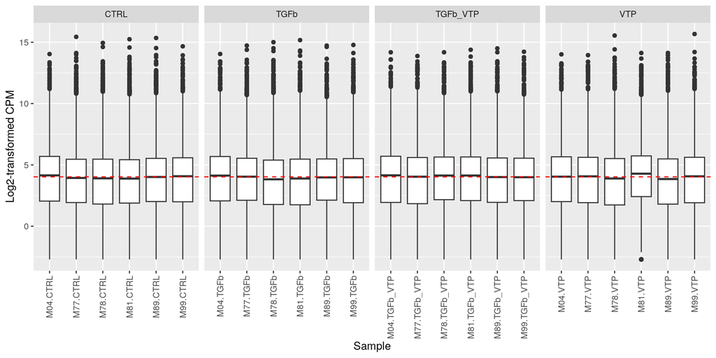

```r
# Log2-transform the CPM values
expr_log2_cpm <- edgeR::cpm(expr[2:25], log = TRUE)

# Boxplot of the log2-transformed CPM values
# We will use the ggplot2 package to construct the boxplot

# Convert the data frame to a long format
expr2Boxplot <- data.frame(expr_log2_cpm)
expr2Boxplot$gname <- rownames(expr2Boxplot)
expr2Boxplot <- reshape2::melt(expr2Boxplot, id.vars = "gname")

# Specify treatment conditions for each sample
expr2Boxplot$Treatment <- gsub("M[0-9]{2}\\.", "", expr2Boxplot$variable)

# Median log2-CPM across samples
median <- median(apply(expr_log2_cpm, 2, median))

# Plot the boxplot
# A horizontal line is added to indicate the median log2-CPM across samples
pNoNorm <- ggplot(expr2Boxplot, aes(x = variable, y = value)) +
    geom_boxplot() +
    theme(axis.text.x = element_text(angle = 90, hjust = 1, vjust = 0.5)) +
    labs(x = "Sample", y = "Log2-transformed CPM") +
    geom_hline(yintercept = median, color = "red", linetype = "dashed") +
    facet_wrap(~Treatment, nrow = 1, scales = "free_x")

pNoNorm
```

**Figure 2.** Expression of cSt-Cs under mechanical strain with pharmacological treatments

We observed a median log2-CPM of 4.0257766 across all samples. The boxplot is grouped into treatment conditions, where variations are relatively small within each condition. Furthermore, we also observed few variations across conditions. Additionally, the data is observed to be slightly skewed to the high expression values. However, we do not observe outliers in the data. This suggests that the data is fairly consistent across the samples and shows no obvious outliers.

### 6.1.2 Data Distribution - Density Plot

To further examine the distribution of expression values across the samples, we plotted a density plot.

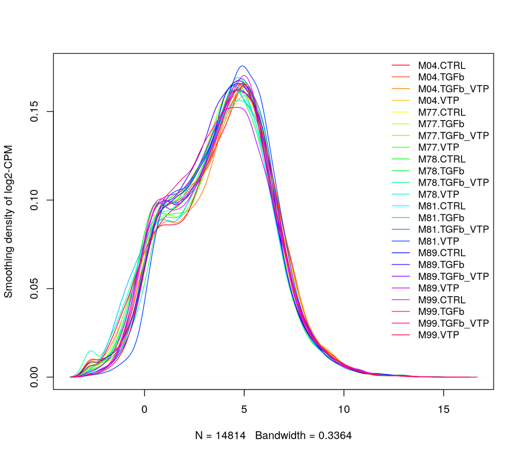

```r
# Density counting
densityCounts <- apply(expr_log2_cpm, 2, density)

# Calculate x, y limits across all samples
xlim <- 0
ylim <- 0
for (i in 1:length(densityCounts)) {
    xlim <- range(c(xlim, densityCounts[[i]]$x))
    ylim <- range(c(ylim, densityCounts[[i]]$y))
}

# Initialize line colours and type
cols <- rainbow(length(densityCounts))
ltys <- rep(1, length(densityCounts))

# Plot initialization
plot(densityCounts[[1]], xlim = xlim, ylim = ylim, type = "n", ylab = "Smoothing density of log2-CPM",
    main = "")

# Adding each samples via a loop
for (i in 1:length(densityCounts)) {
    lines(densityCounts[[i]], col = cols[i], lty = ltys[i])
}

# Add legend
legend("topright", legend = colnames(expr_log2_cpm), col = cols, lty = ltys, cex = 0.9,
    text.col = "black", bty = "n", merge = TRUE, bg = "grey90")
```

**Figure 3.** Density distribution of cSt-Cs gene expression across samples

The density plot reveals that the data is not normally distributed. A second peak is observed toward the left of the distribution. Additionally, some samples also reveal a small peak at the very left of the distribution. This is also observed in several other RNAseq studies before and after normalizations.<sup>20</sup> Comparatively, some variations are observed across the samples. However, these variations do not seem to be extreme. Therefore, we will proceed with the normalization step.

## 6.2 Normalization

### 6.2.1 Normalization Methods

Normalization aims to reduce the variations across samples. It is highly important in the data preparation workflow for RNAseq analysis as it could significantly affect the result. According to the edgeR protocol for analyzing RNAseq data based on count values, Trimmed Mean of M-values (TMM) normalization is recommended for most cases.<sup>16</sup> TMM is based on the assuption that most genes are not differentially expressed, and that upregalted genes in one sample are likely to be downregulated in others correspondingly.<sup>21</sup> Since in the previous steps we observed that the distributions of the expression values are relatively consistent across samples, we would expect that TMM as a robust normalization method to account for highly differentially expressed genes which could in turn negatively impact the normalization process.<sup>21</sup>

### 6.2.2 Applying TMM Normalization

Here we apply the TMM normalization using the edgeR package.

```r
# Convert raw counts data frame to a matrix
expr_matrix <- as.matrix(expr[2:25])
rownames(expr_matrix) <- expr$gname

# Create a DGEList object
expr_dge <- edgeR::DGEList(counts = expr_matrix, group = samples$treatment)

# Apply TMM normalization
expr_dge <- edgeR::calcNormFactors(expr_dge)

# Extract normalized CPM values for normalized counts
expr_norm_cpm <- edgeR::cpm(expr_dge)
```

## 6.3 Post-normalization Comparative Statistics

Following normalization, we will perform a comparative analysis of the normalized data with the original count data. We expect a more consistent distribution of the expression values across samples after normalization.

### 6.3.1 Boxplot

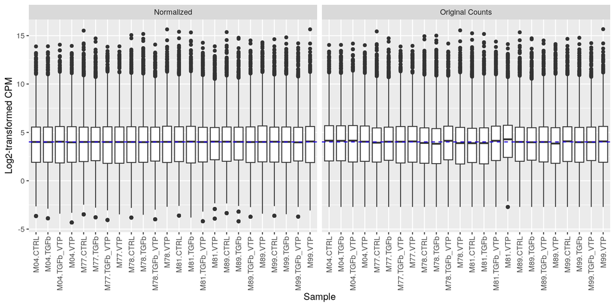

```r
# Log2-transform the CPM values
expr_norm_log2_cpm <- log2(expr_norm_cpm)

# Convert the data frame to a long format
normExpr2Boxplot <- data.frame(expr_norm_log2_cpm)
normExpr2Boxplot$gname <- rownames(normExpr2Boxplot)
normExpr2Boxplot <- reshape2::melt(normExpr2Boxplot, id.vars = "gname")

# Setting group variable for normalized and unnormalized data
normExpr2Boxplot$normalized <- "Normalized"
expr2Boxplot <- expr2Boxplot[ , -4]
expr2Boxplot$normalized <- "Original Counts"

# Combine normalized and unnormalized data for plotting
compExpr2Boxplot <- rbind(expr2Boxplot, normExpr2Boxplot)

# Median log2-CPM across samples of the normalized data
medianNormalzied <- median(apply(expr_norm_log2_cpm, 2, median))

# Plot the boxplot
# A horizontal line is added to indicate the median log2-CPM across samples
ggplot(compExpr2Boxplot, aes(x = variable, y = value)) +
    geom_boxplot() +
    theme(axis.text.x = element_text(angle = 90, hjust = 1, vjust = 0.5)) +
    labs(x = "Sample", y = "Log2-transformed CPM") +
    geom_hline(yintercept = median, color = "red", linetype = "dashed",
        show.legend = "Median of original counts") +
    geom_hline(yintercept = medianNormalzied, color = "blue", linetype = "dashed",
        show.legend = "Median of normalized counts") +
    facet_wrap(~normalized, nrow = 1, scales = "free_x")
```

**Figure 4.** Comparative expression of cSt-Cs under mechanical strain with pharmacological treatments before and after TMM normalization

The boxplots shows a highly consistent boxplot distribution across samples. In comparison to the unnormalized counts, the median of the samples are similar. However, the interquartile range and the median acorss samples are more consistent after normalization. Interestingly, R reports some expression values becoming outliers after normalziation. This may be a result of the global shift of the distribution to the lower end. This hypothesis is supported by the observation of more genes considered lowly expressed after normalization.

### 6.3.2 Density Plot

To further assess the global shift of the distribution, we plot the density distribution of the expression values across samples.

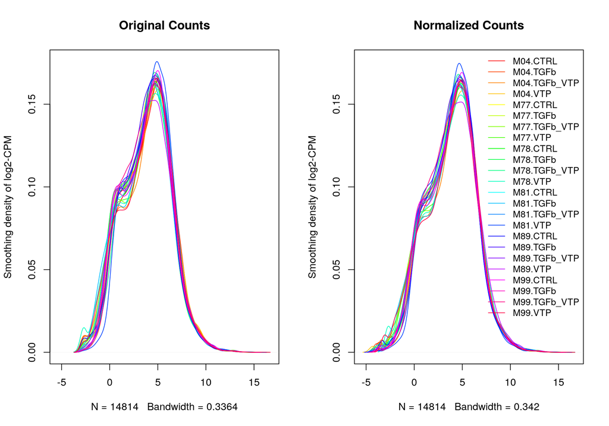

```r
# Density counting
normDensityCounts <- apply(expr_norm_log2_cpm, 2, density)

# Calculate x, y limits across all samples
xlimNorm <- 0
ylimNorm <- 0
for (i in 1:length(normDensityCounts)) {
    xlimNorm <- range(c(xlimNorm, normDensityCounts[[i]]$x))
    ylimNorm <- range(c(ylimNorm, normDensityCounts[[i]]$y))
}

# Define range for both plots
xlim[1] <- min(xlim[1], xlimNorm[1])
xlim[2] <- max(xlim[2], xlimNorm[2])
ylim[1] <- min(ylim[1], ylimNorm[1])
ylim[2] <- max(ylim[2], ylimNorm[2])

# Initialize line colours and type
cols <- rainbow(length(normDensityCounts))
ltys <- rep(1, length(normDensityCounts))

# Plotting the normalized and original density plots together
par(mfrow = c(1, 2))

# Density plot of original counts
plot(densityCounts[[1]], xlim = xlim, ylim = ylim, type = "n", ylab = "Smoothing density of log2-CPM",
    main = "Original Counts")
# Adding each samples via a loop
for (i in 1:length(densityCounts)) {
    lines(densityCounts[[i]], col = cols[i], lty = ltys[i])
}

# Density plot of normalized counts
plot(normDensityCounts[[1]], xlim = xlim, ylim = ylim, type = "n", ylab = "Smoothing density of log2-CPM",
    main = "Normalized Counts")
# Adding each samples via a loop
for (i in 1:length(normDensityCounts)) {
    lines(normDensityCounts[[i]], col = cols[i], lty = ltys[i])
}

# Add legend
legend("topright", legend = colnames(expr_norm_log2_cpm), col = cols, lty = ltys,
    cex = 0.9, text.col = "black", bty = "n", merge = TRUE, bg = "grey90")
```

**Figure 5.** Comparative distribution of cSt-Cs gene expression across samples before and after TMM normalization

In the density plot, we did not observe a global shift of the distribution. In particular, the major peak remains at the same position. However, the variations of the distribution across samples are reduced after normalization, manifested by the more closely aligened lines near the center of the plot. The second peak observed previously is also smoothened after normalization. However, slightly more variations are observed in the normalized data around the high and low end of the distribution.

### 6.3.3 Multidimensional Scaling

A multidimensional scaling (MDS) plot allows for the reduction of the dimensionality of the data to visualize variations across samples using the two most important dimensions. In this case, we visualize the variation of the samples after normalization.

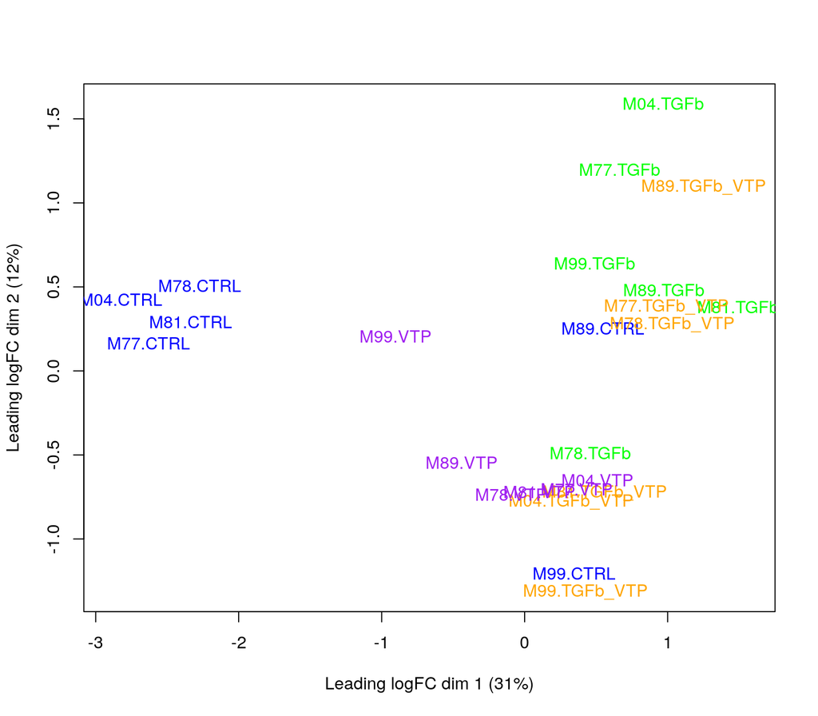

```r
# MDS plot of normalized data
limma::plotMDS(expr_norm_log2_cpm, labels = rownames(samples), col = c("blue", "green",
    "orange", "purple")[factor(samples$treatment)], pch = 19, cex = 1)
```

**Figure 6.** Multidimensional scaling plot of cSt-Cs gene expression across samples after TMM normalization. Samples are coloured by treatment conditions and shows moderate clustering based on treatment conditions.

## 6.4 Saving Normalized Data

Finally, we save the normalized data as a csv file for future analysis.

```r
# Use edgeR to convert the DGEList object to a matrix of normalized counts
expr_norm_matrix <- edgeR::as.matrix.DGEList(expr_dge)

# Save the normalized data as a csv file
write.csv(expr_norm_matrix, file = "./Data/expr_norm_counts.csv", row.names = TRUE)
```

# 7 Interpretation and Analysis

- **What are the control and test conditions of the dataset?**

  The dataset includes 4 treatment conditions, all of them are based on a common backgroud condition. The cardiosphere derived cardiac stromal cells (cSt-Cs) were cultured independently on glass slides, which provides the maximal mechanical strain for the cell cytoskeletons. In the control group, all cells were cultured without any additional pharmacological interventions. In the other three groups, cells were cultured with verteporfin (VTP) alone, TGF-β1 alone, and both VTP and TGF-β1 together. Specifically, the control group serves to examine the antifibrotic effect of VTP, and the TGF-β1 alone serves to control for the effect of VTP in the presence of the potent fibrotic stimulus TGF-β1.<sup>2</sup>

  See study summary for more details.
- **Why is the dataset of interest to you?**

  The dataset is interesting because it uses an in vitro model on a specific pro-fibrotic cell type, cSt-Cs, to examine the mechanism of the fibrosis process that models a particular process in the heart.<sup>22</sup> As shown in various studies, cardiac fribrosis is the most prevalent and lethal phenotype of heart failure. Therefore, understanding how blocking the YAP-TAZ complex using pharmacological agents provides a promising therapeutic strategy for the treatment of heart failure.

  See background for more details.
- **Were there expression values that were not unique for specific genes? How did you handle these?**

  In the original raw counts dataset, we did not observe any duplicated gene names given the mix of HGNC symbols and ENA identifiers. However, we did observe duplicated ENA accession numbers assocaited with different version numbers treated as different genes in the dataset. Since by the nomenclature of [ENA](https://www.ebi.ac.uk/ena/browser/home), the accession numbers are unique identifiers for a specific gene, whereas version numbers are a result of information updates from the orginally submitting author, we decided to treat genes with the same accession number but different version numbers as the same gene. We mapped the accession numbers to the HGNC symbols and sum the raw counts of the duplicated genes (as they are the same gene). In this way, we obtained a dataset of genes with unique HGNC symbols.

  See mapped genes and duplicated ENA IDs for more details.
- **Were there expression values that could not be mapped to current HUGO symbols?**

  Yes. Some expression values could not be mapped to the HUGO symbols. The original dataset provides both HGNC symbols and ENA accession numbers. We tried to map the ENA accession numbers to the HGNC symbols using the [biomaRt](https://bioconductor.org/packages/release/bioc/html/biomaRt.html) package. However, some of the genes are still unable to be mapped, and upon further searching of the genes directly on the ENA website, we found that some of the genes are non-coding RNA and pseudogenes. These may be a result of unspecific mapping or carry over during the poly-A enrichment process. Eiter way, these genes do not appear to be highly expressed, so we keep the ENA accession numbers for downstream analysis.

  See pre-normalization statistics and post-normalization statistics for more details.
- **How many outliers were removed?**

  We did not observe significant outliers before and after normalization, despite a slight increase in the lowly expressed genes after normalization. Hence, we did not remove any outliers from the dataset. The distribution of the normalized data is sufficient for downstream differential gene expression analysis.

  See pre-normalization statistics for more details.
- **How did you handle replicates?**

  See sample matrix and data filtering for more details.
- **What is the final coverage of your dataset?**

  The final dataset comprises:
  - 14814 genes
  - 24 samples
  - 6 biological replicates per treatment condition

  These genes are primarily labelled with HGNC symbols, with a small number of genes labelled with ENA accession numbers.

# 8 Journal Link

The link to the concurrent journal entry can be found [here](https://github.com/bcb420-2023/Jielin_Yang/wiki/Dataset-Cleaning-and-Identifier-Mapping).

# References

1.

Savarese G, Becher PM, Lund LH, Seferovic P, Rosano GM, Coats AJ. Global burden of heart failure: A comprehensive and updated review of epidemiology. *Cardiovascular research*. 2022;118(17):3272-3287.

2.

Garoffolo G, Casaburo M, Amadeo F, et al. Reduction of cardiac fibrosis by interference with YAP-dependent transactivation. *Circulation Research*. 2022;131(3):239-257.

3.

Porter KE, Turner NA. Cardiac fibroblasts: At the heart of myocardial remodeling. *Pharmacology & therapeutics*. 2009;123(2):255-278.

4.

Tallquist MD, Molkentin JD. Redefining the identity of cardiac fibroblasts. *Nature Reviews Cardiology*. 2017;14(8):484-491.

5.

Perestrelo AR, Silva AC, Oliver-De La Cruz J, et al. Multiscale analysis of extracellular matrix remodeling in the failing heart. *Circulation research*. 2021;128(1):24-38.

6.

Brusatin G, Panciera T, Gandin A, Citron A, Piccolo S. Biomaterials and engineered microenvironments to control YAP/TAZ-dependent cell behaviour. *Nature materials*. 2018;17(12):1063-1075.

7.

Panciera T, Azzolin L, Cordenonsi M, Piccolo S. Mechanobiology of YAP and TAZ in physiology and disease. *Nature reviews Molecular cell biology*. 2017;18(12):758-770.

8.

Elosegui-Artola A, Andreu I, Beedle AE, et al. Force triggers YAP nuclear entry by regulating transport across nuclear pores. *Cell*. 2017;171(6):1397-1410.

9.

Francisco J, Zhang Y, Jeong JI, et al. Blockade of fibroblast YAP attenuates cardiac fibrosis and dysfunction through MRTF-a inhibition. *Basic to Translational Science*. 2020;5(9):931-945.

10.

Giraud J, Molina-Castro S, Seeneevassen L, et al. Verteporfin targeting YAP1/TAZ-TEAD transcriptional activity inhibits the tumorigenic properties of gastric cancer stem cells. *International Journal of Cancer*. 2020;146(8):2255-2267.

11.

Piersma B, Bank RA, Boersema M. Signaling in fibrosis: TGF-$\beta$, WNT, and YAP/TAZ converge. *Frontiers in medicine*. 2015;2:59.

12.

Wang J, Karra R, Dickson AL, Poss KD. Fibronectin is deposited by injury-activated epicardial cells and is necessary for zebrafish heart regeneration. *Developmental biology*. 2013;382(2):427-435.

13.

Hua X, Wang YY, Jia P, et al. Multi-level transcriptome sequencing identifies COL1A1 as a candidate marker in human heart failure progression. *BMC medicine*. 2020;18(1):1-16.

14.

Umbarkar P, Ejantkar S, Tousif S, Lal H. Mechanisms of fibroblast activation and myocardial fibrosis: Lessons learned from FB-specific conditional mouse models. *Cells*. 2021;10(9):2412.

15.

Sha Y, Phan JH, Wang MD. Effect of low-expression gene filtering on detection of differentially expressed genes in RNA-seq data. In: *2015 37th Annual International Conference of the IEEE Engineering in Medicine and Biology Society (EMBC)*. IEEE; 2015:6461-6464.

16.

Anders S, McCarthy DJ, Chen Y, et al. Count-based differential expression analysis of RNA sequencing data using r and bioconductor. *Nature protocols*. 2013;8(9):1765-1786.

17.

Pohjolainen L, Ruskoaho H, Talman V. Transcriptomics reveal stretched human pluripotent stem cell-derived cardiomyocytes as an advantageous hypertrophy model. *Journal of Molecular and Cellular Cardiology Plus*. 2022;2:100020.

18.

Deschamps-Francoeur G, Simoneau J, Scott MS. Handling multi-mapped reads in RNA-seq. *Computational and structural biotechnology journal*. 2020;18:1569-1576.

19.

Li B, Ruotti V, Stewart RM, Thomson JA, Dewey CN. RNA-seq gene expression estimation with read mapping uncertainty. *Bioinformatics*. 2010;26(4):493-500.

20.

Hart T, Komori HK, LaMere S, Podshivalova K, Salomon DR. Finding the active genes in deep RNA-seq gene expression studies. *BMC genomics*. 2013;14:1-7.

21.

Robinson MD, Oshlack A. A scaling normalization method for differential expression analysis of RNA-seq data. *Genome biology*. 2010;11(3):1-9.

22.

Ahmed A, Syed JN, Chi L, et al. KDM8 epigenetically controls cardiac metabolism to prevent initiation of dilated cardiomyopathy. *Nature Cardiovascular Research*. Published online February 13, 2023. doi:10.1038/s44161-023-00214-0